# Bartosz Czech - Interactive Portfolio

## 🏥 Clinical & Stats

**Focus:** Survival, Longitudinal Models, Meta-Analysis, and Correlations.

### Forest Plot (Meta-analysis)

*Odds Ratios visualization.*

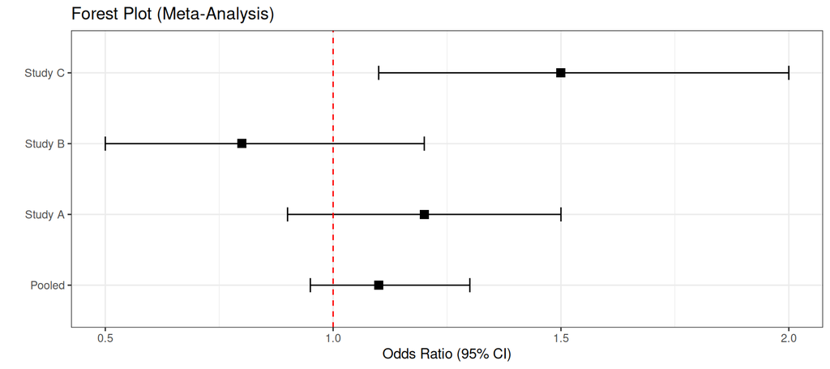

```r
df_f <- data.frame(
  Study=c("Study A", "Study B", "Study C", "Pooled"),
  OR=c(1.2, 0.8, 1.5, 1.1),
  Low=c(0.9, 0.5, 1.1, 0.95),
  High=c(1.5, 1.2, 2.0, 1.3)
)
ggplot(df_f, aes(y=Study, x=OR, xmin=Low, xmax=High)) +
  geom_point(size=3, shape=15) + geom_errorbarh(height=0.2) +
  geom_vline(xintercept=1, linetype="dashed", color="red") +
  theme_bw() + labs(title="Forest Plot (Meta-Analysis)", x="Odds Ratio (95% CI)", y="")
```

### Survival Analysis (Kaplan-Meier)

*Time-to-event analysis with realistic censoring.*

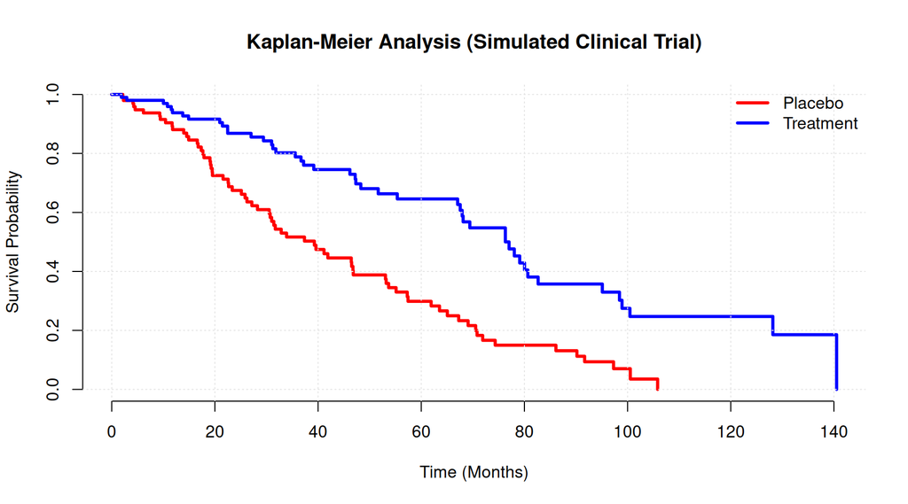

```r
n <- 100
# Generate Weibull distributed times (more realistic for biological failure)
T_treat <- rweibull(n, shape = 1.5, scale = 100)
T_placebo <- rweibull(n, shape = 1.5, scale = 60) # Placebo dies faster

# Combine
df_surv <- data.frame(
  Time = c(T_treat, T_placebo),
  Group = rep(c("Treatment", "Placebo"), each = n)
)

# Add random censoring (patients leaving study)
cens_time <- runif(2*n, 0, 150)
df_surv$Status <- ifelse(df_surv$Time < cens_time, 1, 0) # 1=Event, 0=Censored
df_surv$TimeObs <- pmin(df_surv$Time, cens_time)

fit <- survfit(Surv(TimeObs, Status) ~ Group, data = df_surv)

# Plot
plot(fit, col=c("red", "blue"), lwd=3, xlab="Time (Months)", ylab="Survival Probability",
     main="Kaplan-Meier Analysis (Simulated Clinical Trial)", frame.plot=FALSE)
legend("topright", levels(factor(df_surv$Group)), col=c("red", "blue"), lwd=3, bty="n")
grid(col="grey90")
```

### Linear Mixed Models (LMM)

*Longitudinal data with realistic subject variance.*

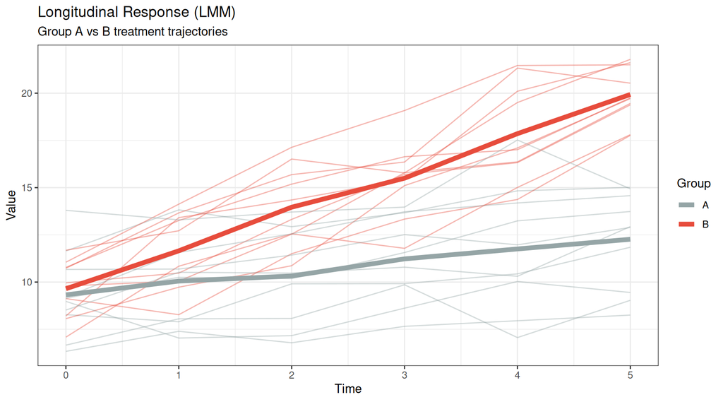

```r
subjects <- 20
times <- 0:5
# Random intercepts and slopes
intercepts <- rnorm(subjects, 10, 2)
slopes <- rnorm(subjects, 0.5, 0.2)

df_lmm <- data.frame()
for(i in 1:subjects){
  # Add group effect: Group B increases faster
  grp <- ifelse(i > 10, "B", "A")
  slope_eff <- slopes[i] + ifelse(grp=="B", 1.5, 0)

  y <- intercepts[i] + slope_eff * times + rnorm(length(times), 0, 1)
  df_lmm <- rbind(df_lmm, data.frame(ID=paste0("S",i), Time=times, Value=y, Group=grp))
}

ggplot(df_lmm, aes(x=Time, y=Value, group=ID, color=Group)) +
  geom_line(alpha=0.4) +
  stat_summary(aes(group=Group), fun=mean, geom="line", size=2) +
  scale_color_manual(values=c("#95a5a6", "#e74c3c")) +
  theme_bw() +
  labs(title="Longitudinal Response (LMM)", subtitle="Group A vs B treatment trajectories")
```

### Correlation Matrix

*Clinical variable relationships.*

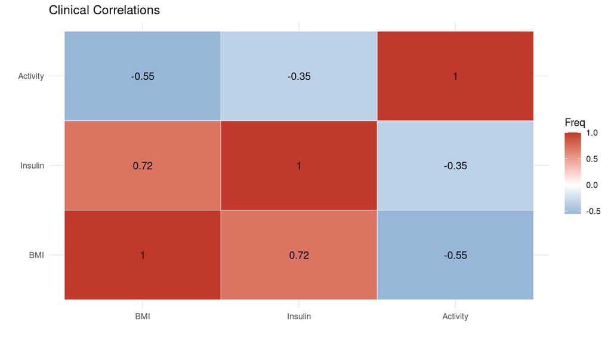

```r
# Simulate correlated multivariate data
sigma <- matrix(c(1, 0.8, -0.5, 0.8, 1, -0.3, -0.5, -0.3, 1), 3, 3)
data_corr <- mvrnorm(n = 50, mu = c(0,0,0), Sigma = sigma)
colnames(data_corr) <- c("BMI", "Insulin", "Activity")
cormat <- round(cor(data_corr), 2)
melted <- as.data.frame(as.table(cormat))

ggplot(melted, aes(Var1, Var2, fill=Freq)) +
  geom_tile(color="white") +
  geom_text(aes(label=Freq)) +
  scale_fill_gradient2(low="#2980b9", mid="white", high="#c0392b") +
  theme_minimal() + labs(title="Clinical Correlations", x="", y="")
```

## 🦠 Microbiome

**Focus:** Community Diversity and Composition.

### Alpha Diversity

*Comparing species richness (Non-normal distributions).*

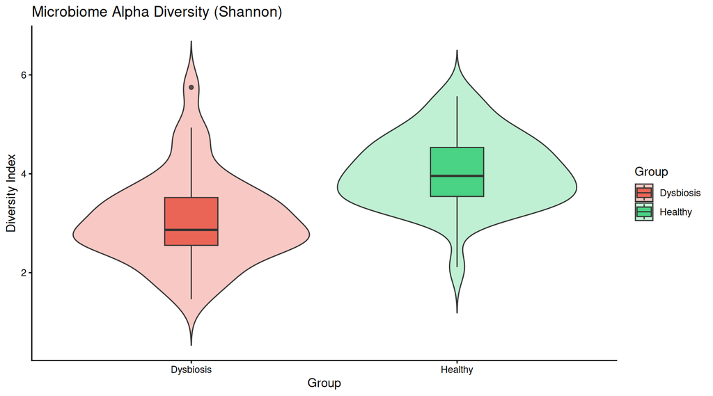

```r
# Generate Gamma distributed data (common for counts/diversity)
grp_a <- rgamma(40, shape=20, scale=0.2)
grp_b <- rgamma(40, shape=15, scale=0.2)

df_alpha <- data.frame(Index = c(grp_a, grp_b), Group = rep(c("Healthy", "Dysbiosis"), each=40))

ggplot(df_alpha, aes(x=Group, y=Index, fill=Group)) +
  geom_violin(alpha=0.3, trim=FALSE) +
  geom_boxplot(width=0.2, alpha=0.8) +
  scale_fill_manual(values=c("#e74c3c", "#2ecc71")) +
  theme_classic() +
  labs(title="Microbiome Alpha Diversity (Shannon)", y="Diversity Index")
```

### Beta Diversity (PCoA)

*Visualizing community separation.*

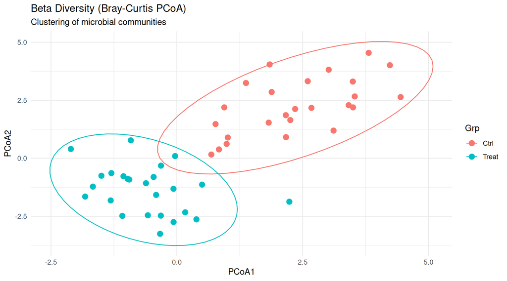

```r
# Create two multivariate normal distributions
g1 <- mvrnorm(25, mu=c(2, 2), Sigma=matrix(c(1,0.5,0.5,1),2))
g2 <- mvrnorm(25, mu=c(-1, -1), Sigma=matrix(c(1,-0.2,-0.2,1),2))
df_beta <- rbind(data.frame(g1, Grp="Ctrl"), data.frame(g2, Grp="Treat"))
colnames(df_beta)[1:2] <- c("PCoA1", "PCoA2")

ggplot(df_beta, aes(PCoA1, PCoA2, color=Grp)) +
  geom_point(size=3) +
  stat_ellipse() +
  theme_minimal() +
  labs(title="Beta Diversity (Bray-Curtis PCoA)", subtitle="Clustering of microbial communities")
```

# 🎤 Conferences & Presentations

## 🗣️ Talks

- **Jaśkowski, B., Czech, B., & Niżański, W. (2023)** Evaluation of the size of the recipient’s corpus luteum after synchronization as an additional criterion for increasing the pregnancy rate after an embryo transfer in cattle. *Japan-Poland Joint Seminar in Morioka, Japan.*
- **Czech, B., Szyda, J., & Wang, Y. (2022)** Host transcriptome and microbiome data integration in Chinese Holstein cattle under heat stress. *73rd Annual Meeting of the European Federation of Animal Science in Porto, Portugal.*
- **Czech, B., Wang, K., Chen, S., Wang, Y., & Szyda, J. (2021)** Faecal microbiota and their association with heat stress in Bos taurus. *72nd Annual Meeting of the European Federation of Animal Science in Davos, Switzerland.*
- **Suchocki, T., Czech, B., Siwek, M., & Szyda, J. (2019)** Breed specific reference genomes in cattle. *70th Annual Meeting of the European Federation of Animal Science in Ghent, Belgium.*
- **Czech, B., Suchocki, T., & Szyda, J. (2019)** SNP prioritisation in GWAS with dense marker sets. *70th Annual Meeting of the European Federation of Animal Science in Ghent, Belgium.*
- **Czech, B., Zając, M., Wasyl, D., Mielczarek, M., & Sztromwasser, P. (2019)** Optimization of de novo assembly of genomes based on second and third generation sequencing data. *XXIV International Conference of Student Scientific Circles, Wroclaw, Poland.*
- **Czech, B., Mielczarek, M., Frąszczak, M., & Szyda, J. (2018)** Breed specific reference genomes in cattle. *69th Annual Meeting of the European Federation of Animal Science in Dubrovnik, Croatia.*
- **Czech, B. (2018)** Construction of Bos taurus breed specific reference genomes. *XXIII International Conference of Student Scientific Circles, Wroclaw, Poland.*
- **Czech, B., Dobkowski, E., Mielczarek, M., Frąszczak, M., & Szyda, J. (2017)** Construction of Bos taurus breed specific reference genomes for Fleckvieh, Simmental, Guernsey and Brown Swiss. *Vorttragstagung der DGfZ und GfT, Stuttgart, Germany.*
- **Czech, B., Dobkowski, E., Barski, P., & Odziemczyk, M. (2017)** Creating of the Brown Swiss breed specific reference genome. *XXII International Conference of Student Scientific Circles, Wroclaw, Poland.*

## 🖼️ Posters

- **Stępień, R., Szyda, J., Czech, B., Mielczarek M. (2023)** The effect of transcriptomic annotations in breast cancer differential gene expression study. *17th Int. Symposium on Integrative Bioinformatics, Wroclaw, Poland.*
- **Czech, B., Szyda, J., & Wang, Y. (2022)** Host transcriptome and microbiome data integration in Chinese Holstein cattle under heat stress. *73rd Annual Meeting EAAP, Porto, Portugal.*
- **Czech, B., Wang, K., Chen, S., Wang, Y., & Szyda, J. (2021)** Challenges of 16S rRNA gene analysis in Chinese Holstein cows under heat stress condition. *72nd Annual Meeting EAAP, Davos, Switzerland.*
- **Kotlarz, K., Mielczarek, M., Suchocki, T., Czech, B., Guldbrandtsen, B., & Szyda, J. (2020)** Don’t play too much! Deep learning to classify true and false positive SNPs in whole genome sequence. *71st Annual Meeting EAAP, Porto, Portugal.*
- **Czech, B., Szyda, J., Wang, K., Chen, S., & Wang, Y. (2020)** The effect of pipelines and databases on the analysis of the fecal microbiota of dairy cattle. *71st Annual Meeting EAAP, Porto, Portugal.*
- **Szyda, J., Czech, B., Wang, K., Chen, S., & Wang, Y. (2020)** The application of mixed linear models for the analysis of microbiome influence on heat stress in Chinese Holstein cows. *71st Annual Meeting EAAP, Porto, Portugal.*
- **Czech, B., Szyda, J., & Guldbrandtsen, B. (2020)** Patterns of DNA variation between the autosomes, the X chromosome and the Y chromosome in Bos taurus genome. *Conference of Polish Bioinformatics Society, Warsaw, Poland.*
- **Kotlarz, K., Mielczarek, M., Suchocki, T., Czech, B., Guldbrandtsen, B., & Szyda, J. (2020)** Deep learning algorithms for the imbalanced classification of correct and incorrect SNP genotypes from WGS pipeline. *Conference of Polish Bioinformatics Society, Warsaw, Poland.*
- **Czech, B., Guldbrandtsen, B., & Szyda, J. (2019)** Pattern of genetic variation between autosomes and sex chromosomes in Bos taurus genome. *70th Annual Meeting EAAP, Ghent, Belgium.*

# End

© 2026 Bartosz Czech. All rights reserved.

Built with R Markdown. Let’s connect: bartosz.w.czech@gmail.com